# TiDEomics Application: Macrophage response to six immune stimuli

```
#> The following groups are missing in the custom palette: PC1_top+, PC1_top-, PC2_top+, PC2_top-, PC3_top+
#> The following groups are missing in the custom palette: PC1_top+, PC1_top-, PC2_top+, PC2_top-, PC3_top+
#> The following groups are missing in the custom palette: PC1_top+, PC1_top-, PC2_top-, PC3_top+
```

[figure not shown]

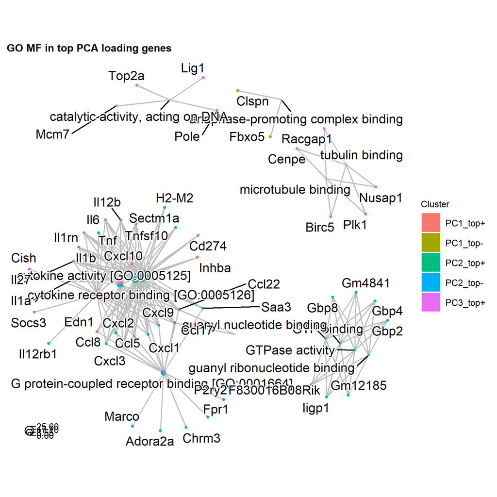

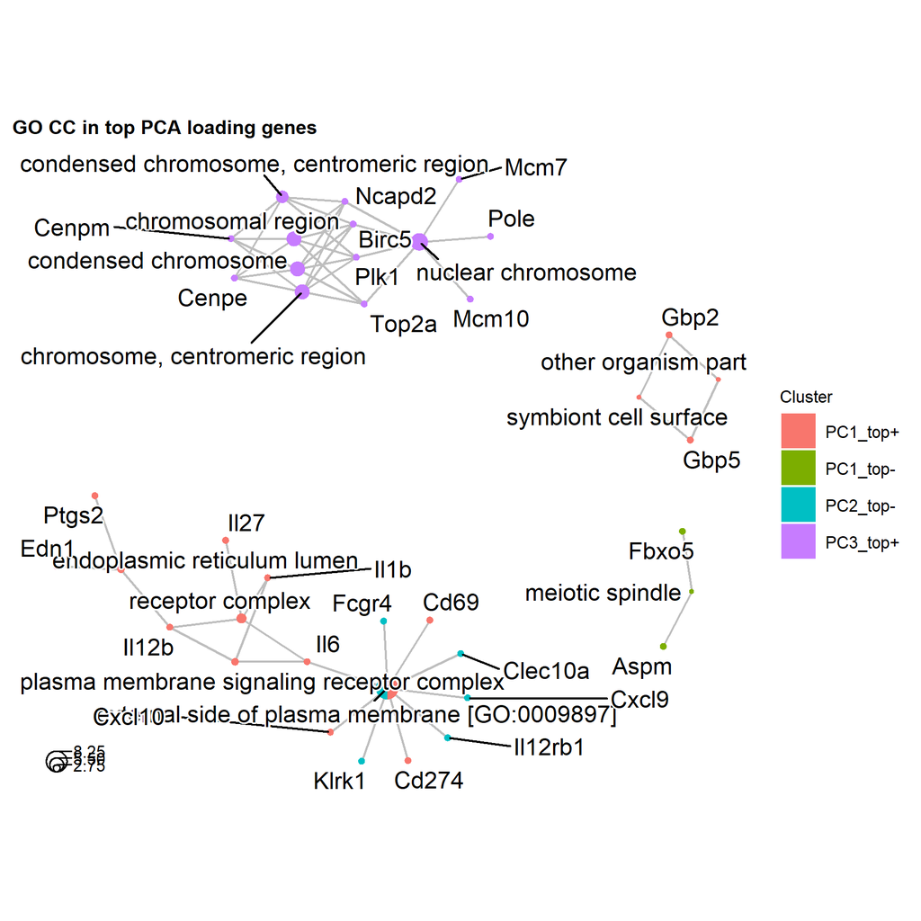

```r
plot_GO(go_list_pca$all,
    plot_dotplot = FALSE,
    plot_cnetplot = TRUE,
    showCategory_cnetplot = 5,
    label = "top PCA loading genes"
)
```

[output not shown]

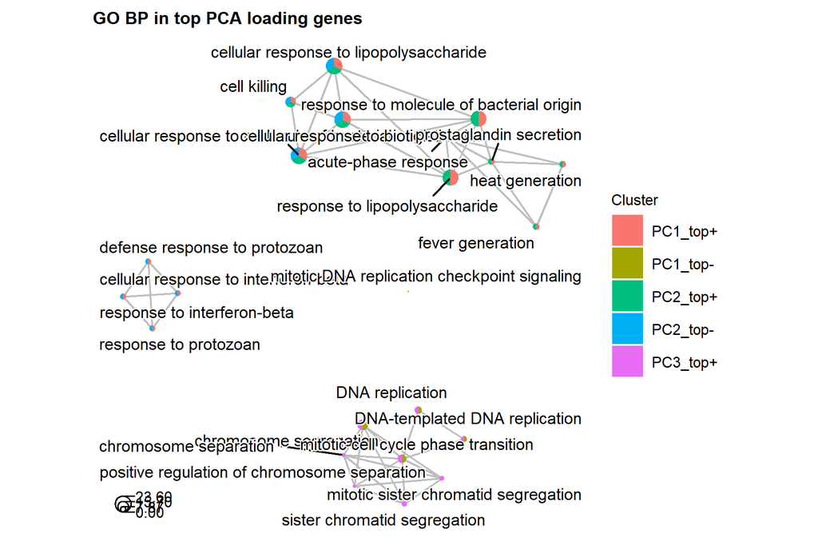

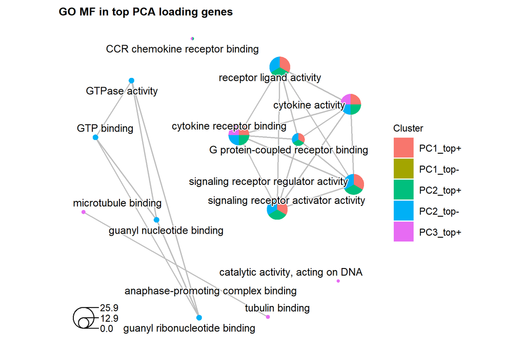

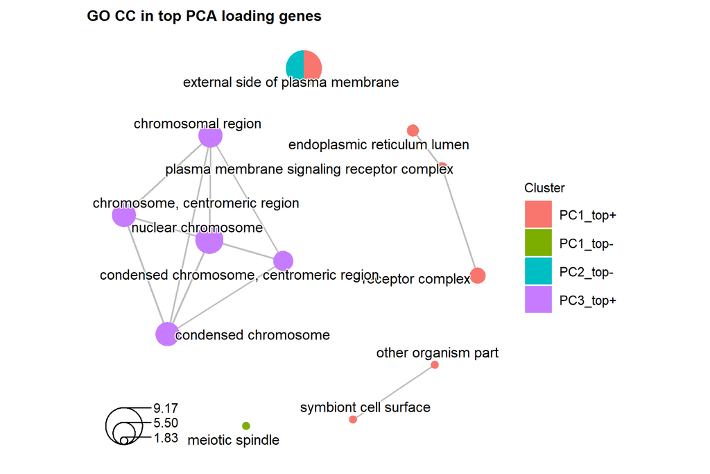

```r
plot_GO(go_list_pca$all,
    plot_dotplot = FALSE,
    plot_emapplot = TRUE,
    showCategory_emapplot = 5,
    label = "top PCA loading genes")
```

## 7.2 Replicates merged by mean

```
#> Group not specified. Plotting all groups: Candida, IFNbeta, IFNgamma, LCMV, Listeria, LPS, untreated
```

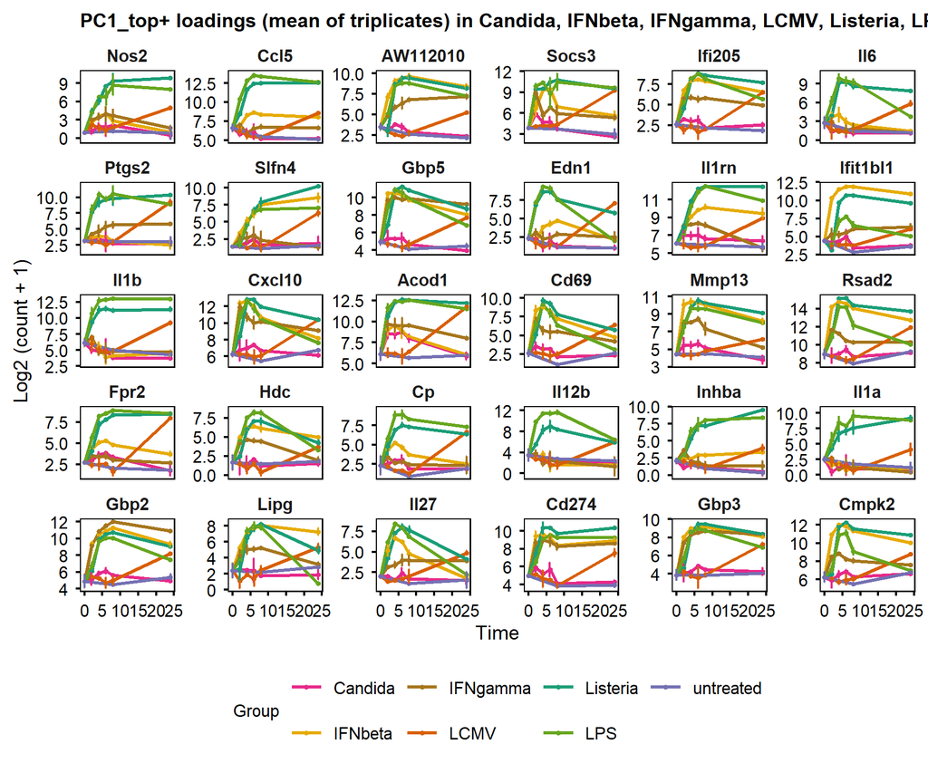

```
#> Group not specified. Plotting all groups: Candida, IFNbeta, IFNgamma, LCMV, Listeria, LPS, untreated
```

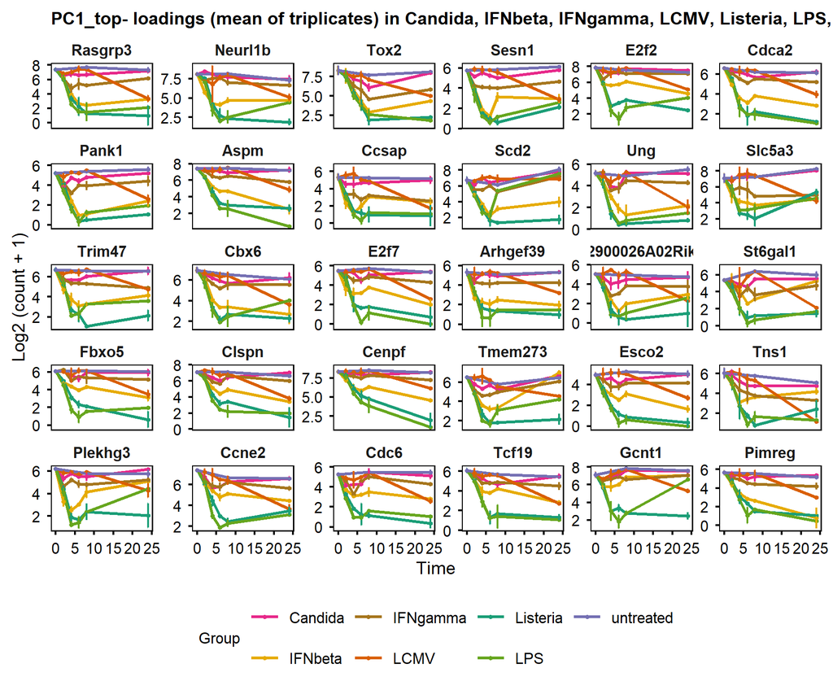

```
#> Group not specified. Plotting all groups: Candida, IFNbeta, IFNgamma, LCMV, Listeria, LPS, untreated
```

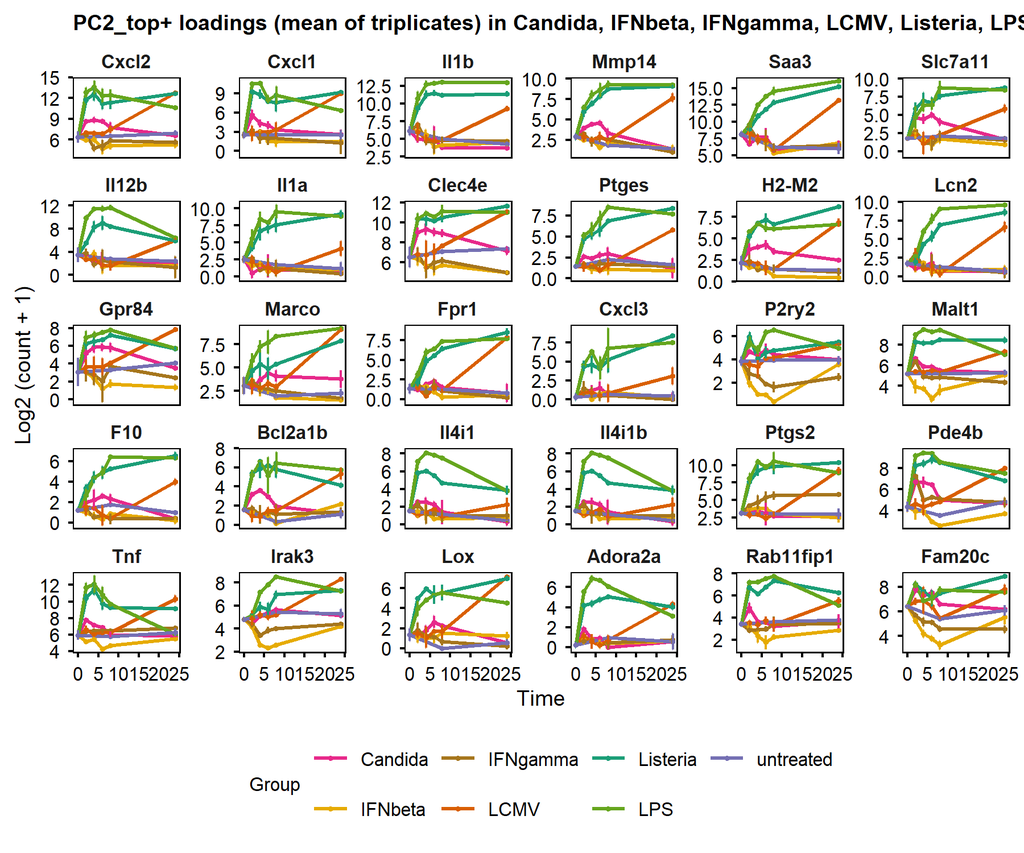

```
#> Group not specified. Plotting all groups: Candida, IFNbeta, IFNgamma, LCMV, Listeria, LPS, untreated
```

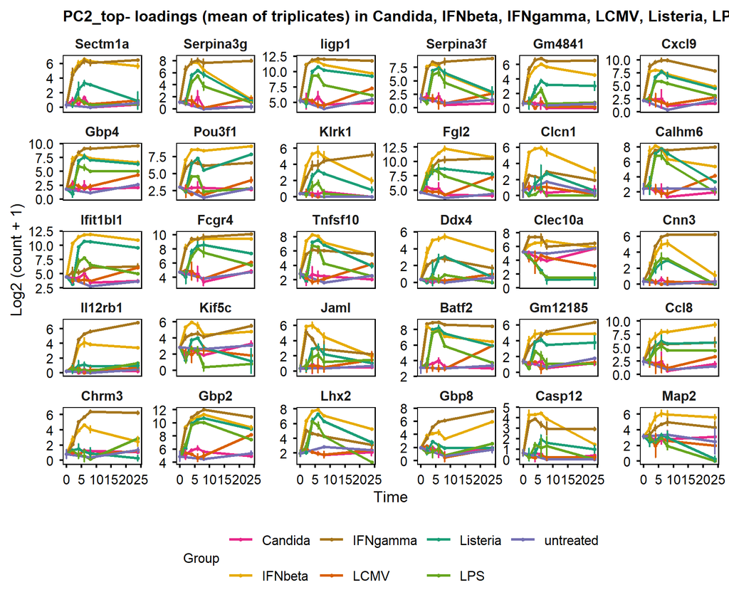

```
#> Group not specified. Plotting all groups: Candida, IFNbeta, IFNgamma, LCMV, Listeria, LPS, untreated
```

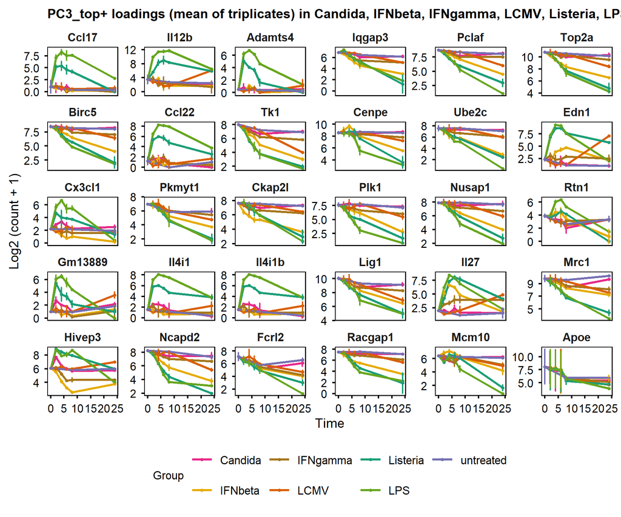

```
#> Group not specified. Plotting all groups: Candida, IFNbeta, IFNgamma, LCMV, Listeria, LPS, untreated
```

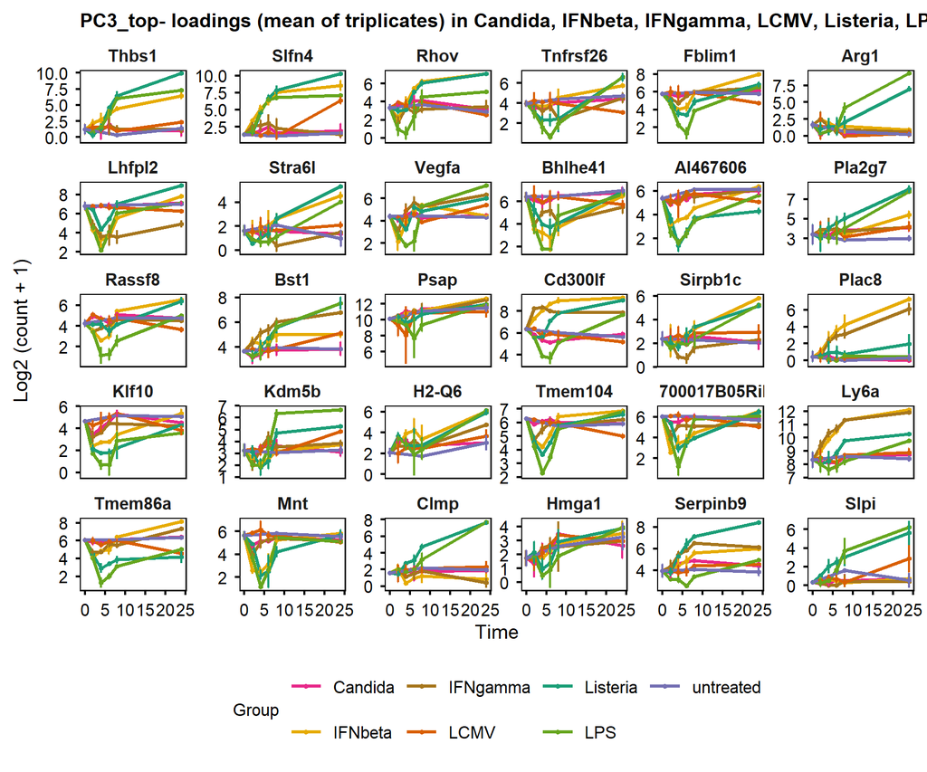

```r
pca_loadings_merged <- PC_merged$loadings |> as.data.frame()
loadings_list_merged <- list()
top_n <- 30

for (i in 1:3) {
    loadings_list_merged[[paste0("PC", i, "_top+")]] <- pca_loadings_merged |>
        arrange(desc(get(paste0("PC", i)))) |>
        head(top_n) |>
        row.names()
    loadings_list_merged[[paste0("PC", i, "_top-")]] <- pca_loadings_merged |>
        arrange(get(paste0("PC", i))) |>
        head(top_n) |>
        row.names()
}

for (i in names(loadings_list_merged)) {
    print(plot_trend(table_mean_sd_orig,
        features = loadings_list_merged[[i]],
        title = paste0(i, " loadings (mean of triplicates)"),
        ylabel = "Log2 (count + 1)"
    ))
}
```

### 7.2.1 GO enrichment

```r
background_pca_merged <- row.names(pca_loadings_merged)

go_list_pca_merged <- enrichGO_list(
    gene_list = loadings_list_merged,
    OrgDb = org.Mm.eg.db,
    universe = background_pca_merged,
    keyType = "SYMBOL",
    simplify = FALSE
)
```

```
#> GO category not specified. Using all three: BP, MF, CC.
#> Performing GO enrichment for category: BP
#> Processing gene list: PC1_top+
#> Processing gene list: PC1_top-
#> Processing gene list: PC2_top+
#> Processing gene list: PC2_top-
#> Processing gene list: PC3_top+
#> Processing gene list: PC3_top-
#> Performing GO enrichment for category: MF
#> Processing gene list: PC1_top+
#> Processing gene list: PC1_top-
#> Processing gene list: PC2_top+
#> Processing gene list: PC2_top-
#> Processing gene list: PC3_top+
#> Processing gene list: PC3_top-
#> Performing GO enrichment for category: CC
#> Processing gene list: PC1_top+
#> Processing gene list: PC1_top-
#> Processing gene list: PC2_top+
#> Processing gene list: PC2_top-
#> Processing gene list: PC3_top+
#> Processing gene list: PC3_top-
#> Merging GO enrichment results across gene lists for each category.
```

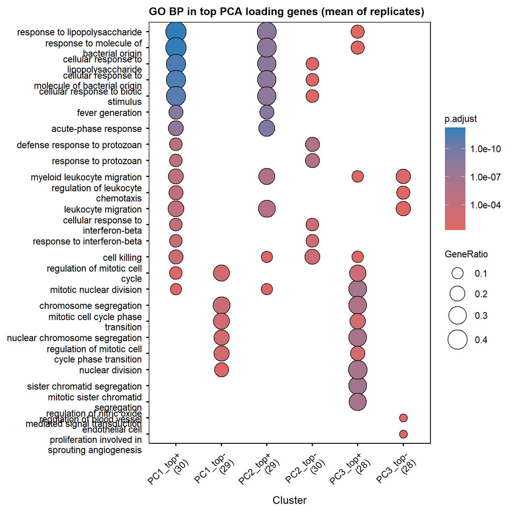

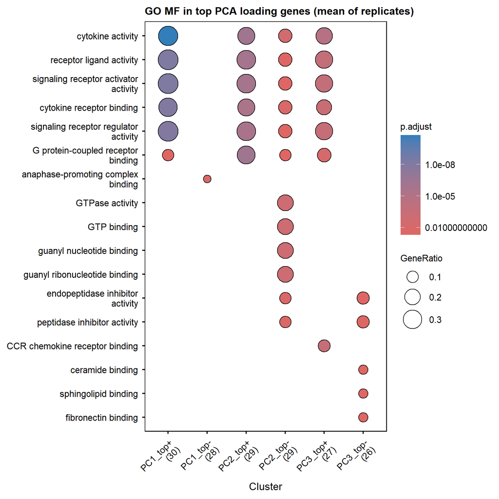

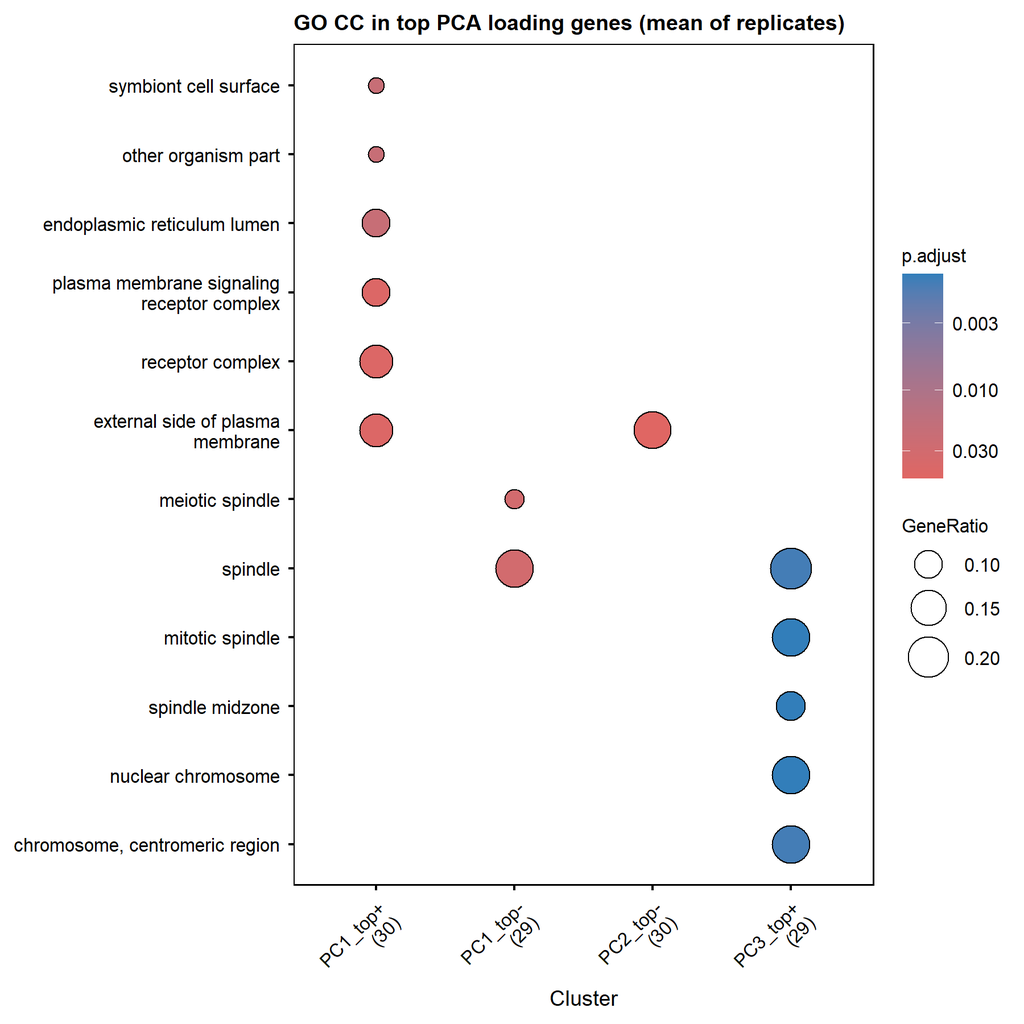

```r
plot_GO(go_list_pca_merged$all,
    plot_dotplot = TRUE,
    showCategory_dotplot = 5,
    label = "top PCA loading genes (mean of replicates)"
)
```

```
#> The following groups are missing in the custom palette: PC1_top+, PC1_top-, PC2_top+, PC2_top-, PC3_top+, PC3_top-
#> The following groups are missing in the custom palette: PC1_top+, PC1_top-, PC2_top+, PC2_top-, PC3_top+, PC3_top-
#> The following groups are missing in the custom palette: PC1_top+, PC1_top-, PC2_top-, PC3_top+
```

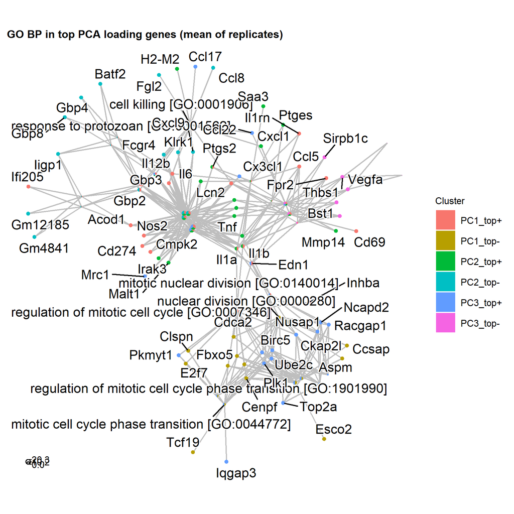

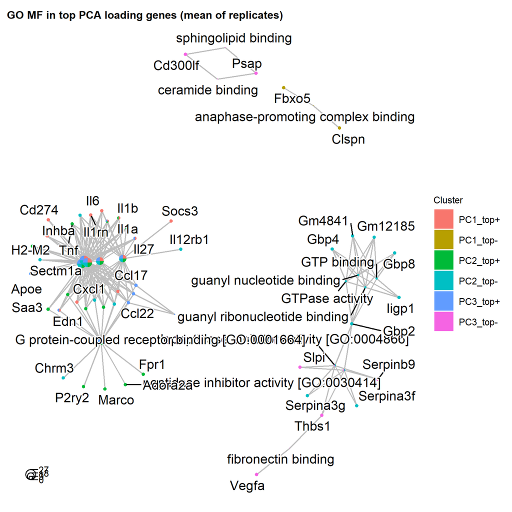

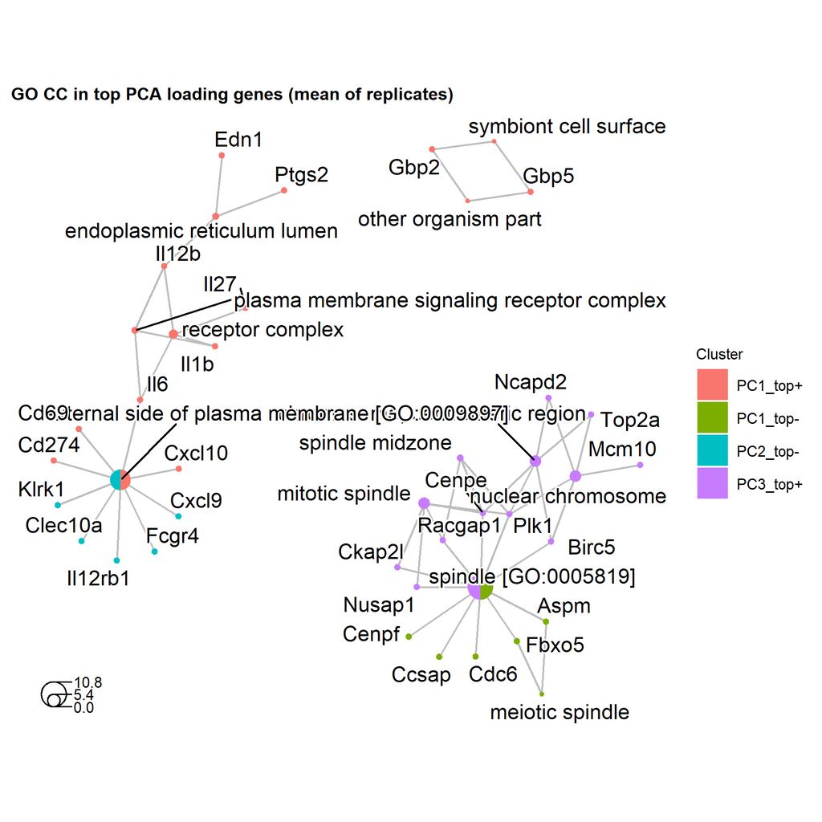

```r
plot_GO(go_list_pca_merged$all,
    plot_dotplot = FALSE,
    plot_cnetplot = TRUE,
    showCategory_cnetplot = 5,
    label = "top PCA loading genes (mean of replicates)"
)
```

[output not shown]

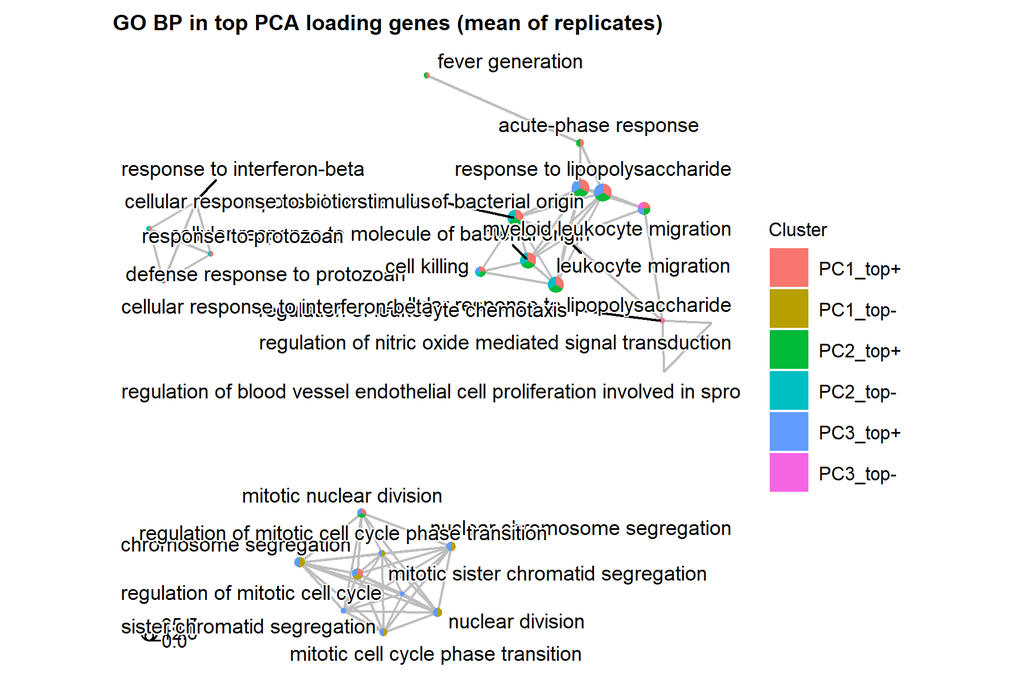

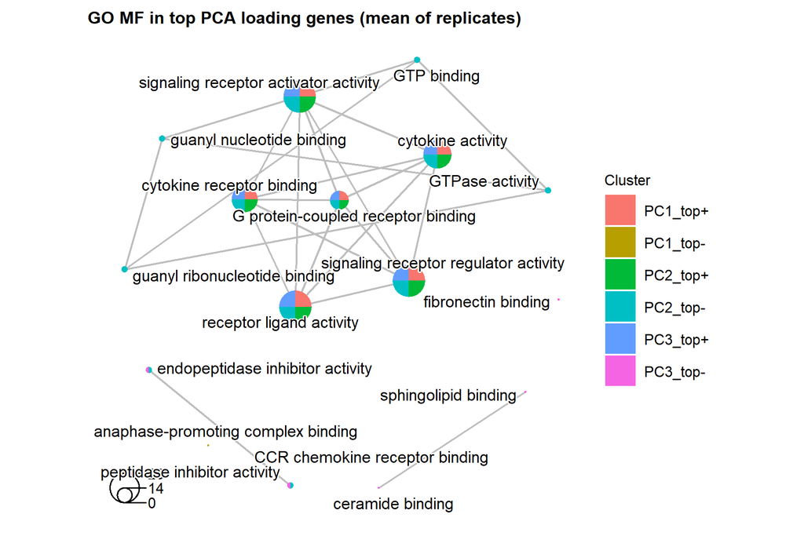

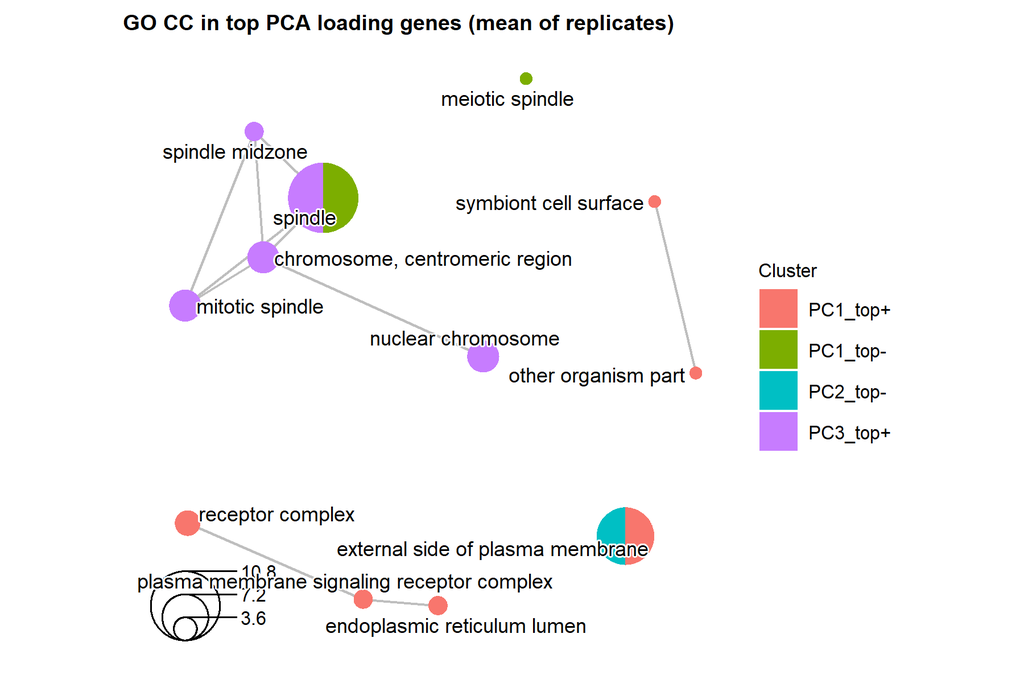

```r
plot_GO(go_list_pca_merged$all,
    plot_dotplot = FALSE,
    plot_emapplot = TRUE,
    showCategory_emapplot = 5,
    label = "top PCA loading genes (mean of replicates)")
```

# 8 Pairwise differential expression (DE)

## 8.1 Between time points within each group

Default DE criteria: p.adj < 0.05, |log2FC| > 1.

`trend = TRUE` is used to model the mean-variance relationship, as recommended for RNA-seq count-derived data and supported by the diagnostics plot.

```r
DE_diagnosis <- DE_between_time(data_obj, assay = 1, filter = 1, trend = FALSE,
    group = "LPS")
```

```
#> Comparing group LPS time 2 to 0: keeping 20150 of 20150 features (100.0%)
#> Comparing group LPS time 4 to 0: keeping 20150 of 20150 features (100.0%)
#> Comparing group LPS time 6 to 0: keeping 20150 of 20150 features (100.0%)
#> Comparing group LPS time 8 to 0: keeping 20150 of 20150 features (100.0%)
#> Comparing group LPS time 24 to 0: keeping 20150 of 20150 features (100.0%)
#> Comparing group LPS time 4 to 2: keeping 20150 of 20150 features (100.0%)
#> Comparing group LPS time 6 to 2: keeping 20150 of 20150 features (100.0%)
#> Comparing group LPS time 8 to 2: keeping 20150 of 20150 features (100.0%)
#> Comparing group LPS time 24 to 2: keeping 20150 of 20150 features (100.0%)
#> Comparing group LPS time 6 to 4: keeping 20150 of 20150 features (100.0%)
#> Comparing group LPS time 8 to 4: keeping 20150 of 20150 features (100.0%)
#> Comparing group LPS time 24 to 4: keeping 20150 of 20150 features (100.0%)
#> Comparing group LPS time 8 to 6: keeping 20150 of 20150 features (100.0%)
#> Comparing group LPS time 24 to 6: keeping 20150 of 20150 features (100.0%)
#> Comparing group LPS time 24 to 8: keeping 20150 of 20150 features (100.0%)
```

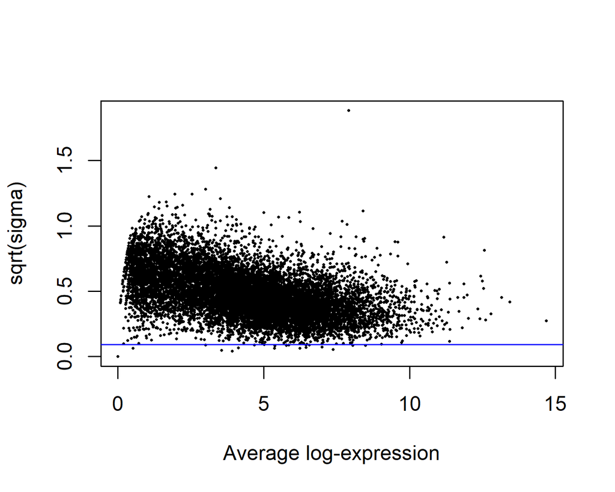

```r
limma::plotSA(DE_diagnosis$fit_list$LPS$`t2-t0`)
```

```r
DE_between_time_out <- DE_between_time(data_obj, assay = 1, filter = 1, trend = TRUE)
```

```
#> Comparing group Candida time 2 to 0: keeping 20150 of 20150 features (100.0%)
#> Comparing group Candida time 4 to 0: keeping 20150 of 20150 features (100.0%)
#> Comparing group Candida time 6 to 0: keeping 20150 of 20150 features (100.0%)
#> Comparing group Candida time 8 to 0: keeping 20150 of 20150 features (100.0%)
#> Comparing group Candida time 24 to 0: keeping 20150 of 20150 features (100.0%)
#> Comparing group Candida time 4 to 2: keeping 20150 of 20150 features (100.0%)
#> Comparing group Candida time 6 to 2: keeping 20150 of 20150 features (100.0%)
#> Comparing group Candida time 8 to 2: keeping 20150 of 20150 features (100.0%)
#> Comparing group Candida time 24 to 2: keeping 20150 of 20150 features (100.0%)
#> Comparing group Candida time 6 to 4: keeping 20150 of 20150 features (100.0%)
#> Comparing group Candida time 8 to 4: keeping 20150 of 20150 features (100.0%)
#> Comparing group Candida time 24 to 4: keeping 20150 of 20150 features (100.0%)
#> Comparing group Candida time 8 to 6: keeping 20150 of 20150 features (100.0%)
#> Comparing group Candida time 24 to 6: keeping 20150 of 20150 features (100.0%)
#> Comparing group Candida time 24 to 8: keeping 20150 of 20150 features (100.0%)
#> Comparing group IFNbeta time 2 to 0: keeping 20150 of 20150 features (100.0%)
#> Comparing group IFNbeta time 4 to 0: keeping 20150 of 20150 features (100.0%)
#> Comparing group IFNbeta time 6 to 0: keeping 20150 of 20150 features (100.0%)
#> Comparing group IFNbeta time 8 to 0: keeping 20150 of 20150 features (100.0%)
#> Comparing group IFNbeta time 24 to 0: keeping 20150 of 20150 features (100.0%)
#> Comparing group IFNbeta time 4 to 2: keeping 20150 of 20150 features (100.0%)
#> Comparing group IFNbeta time 6 to 2: keeping 20150 of 20150 features (100.0%)
#> Comparing group IFNbeta time 8 to 2: keeping 20150 of 20150 features (100.0%)
#> Comparing group IFNbeta time 24 to 2: keeping 20150 of 20150 features (100.0%)
#> Comparing group IFNbeta time 6 to 4: keeping 20150 of 20150 features (100.0%)
#> Comparing group IFNbeta time 8 to 4: keeping 20150 of 20150 features (100.0%)
#> Comparing group IFNbeta time 24 to 4: keeping 20150 of 20150 features (100.0%)
#> Comparing group IFNbeta time 8 to 6: keeping 20150 of 20150 features (100.0%)
#> Comparing group IFNbeta time 24 to 6: keeping 20150 of 20150 features (100.0%)
#> Comparing group IFNbeta time 24 to 8: keeping 20150 of 20150 features (100.0%)
#> Comparing group IFNgamma time 2 to 0: keeping 20150 of 20150 features (100.0%)
#> Comparing group IFNgamma time 4 to 0: keeping 20150 of 20150 features (100.0%)
#> Comparing group IFNgamma time 6 to 0: keeping 20150 of 20150 features (100.0%)
#> Comparing group IFNgamma time 8 to 0: keeping 20150 of 20150 features (100.0%)
#> Comparing group IFNgamma time 24 to 0: keeping 20150 of 20150 features (100.0%)
#> Comparing group IFNgamma time 4 to 2: keeping 20150 of 20150 features (100.0%)
#> Comparing group IFNgamma time 6 to 2: keeping 20150 of 20150 features (100.0%)
#> Comparing group IFNgamma time 8 to 2: keeping 20150 of 20150 features (100.0%)
#> Comparing group IFNgamma time 24 to 2: keeping 20150 of 20150 features (100.0%)
#> Comparing group IFNgamma time 6 to 4: keeping 20150 of 20150 features (100.0%)
```

[output cut: 38 more lines]

```
#> Comparing group LPS time 8 to 0: keeping 20150 of 20150 features (100.0%)
#> Comparing group LPS time 24 to 0: keeping 20150 of 20150 features (100.0%)
#> Comparing group LPS time 4 to 2: keeping 20150 of 20150 features (100.0%)
#> Comparing group LPS time 6 to 2: keeping 20150 of 20150 features (100.0%)
#> Comparing group LPS time 8 to 2: keeping 20150 of 20150 features (100.0%)
#> Comparing group LPS time 24 to 2: keeping 20150 of 20150 features (100.0%)
#> Comparing group LPS time 6 to 4: keeping 20150 of 20150 features (100.0%)
#> Comparing group LPS time 8 to 4: keeping 20150 of 20150 features (100.0%)
#> Comparing group LPS time 24 to 4: keeping 20150 of 20150 features (100.0%)
#> Comparing group LPS time 8 to 6: keeping 20150 of 20150 features (100.0%)
#> Comparing group LPS time 24 to 6: keeping 20150 of 20150 features (100.0%)
#> Comparing group LPS time 24 to 8: keeping 20150 of 20150 features (100.0%)
#> Comparing group untreated time 8 to 0: keeping 20150 of 20150 features (100.0%)
#> Comparing group untreated time 24 to 0: keeping 20150 of 20150 features (100.0%)
#> Comparing group untreated time 24 to 8: keeping 20150 of 20150 features (100.0%)
```

```r
DE_between_time_out$all_list$IFNbeta$`t2-t0` |> head()
```

|  | Feature | Comparison | Group | Cond1 | Cond2 | RNA_IFNbeta_0h_R1_1 | RNA_IFNbeta_0h_R2_1 | RNA_IFNbeta_2h_R1_1 | RNA_IFNbeta_2h_R2_1 | logFC | P.Value | adj.P.Val |
| --- | --- | --- | --- | --- | --- | --- | --- | --- | --- | --- | --- | --- |
| 1 | 0610005C13Rik | t2-t0 | IFNbeta | 0 | 2 | 0.0000000 | 0.0000000 | 0.4011044 | 0.0000000 | 0.20055218 | 3.402764e-01 | 0.730802352 |
| 2 | 0610009E02Rik | t2-t0 | IFNbeta | 0 | 2 | 0.6836615 | 0.3629897 | 0.0000000 | 0.4099347 | -0.31835826 | 2.624566e-01 | 0.730802352 |
| 3 | 0610009L18Rik | t2-t0 | IFNbeta | 0 | 2 | 1.1456267 | 1.2812185 | 1.1903452 | 1.2107022 | -0.01289885 | 9.114232e-01 | 1.000000000 |
| 4 | 0610030E20Rik | t2-t0 | IFNbeta | 0 | 2 | 5.6898198 | 5.9460460 | 5.1928861 | 5.2654116 | -0.58878401 | 2.099708e-02 | 0.238310647 |
| 5 | 0610039K10Rik | t2-t0 | IFNbeta | 0 | 2 | 0.0000000 | 0.0000000 | 0.0000000 | 0.4099347 | 0.20496734 | 3.402761e-01 | 0.730802352 |
| 6 | 0610043K17Rik | t2-t0 | IFNbeta | 0 | 2 | 0.0000000 | 0.0000000 | 0.7146075 | 0.7287924 | 0.72169997 | 1.004596e-05 | 0.002530326 |

```r
DE_between_time_out$de_list$IFNbeta$`t2-t0` |> head()
```

|  | Feature | Comparison | Group | Cond1 | Cond2 | logFC | adj.P.Val |
| --- | --- | --- | --- | --- | --- | --- | --- |
| 1 | 1700017B05Rik | t2-t0 | IFNbeta | 0 | 2 | -3.437573 | 0.01408219 |
| 2 | 9930111J21Rik2 | t2-t0 | IFNbeta | 0 | 2 | 1.481311 | 0.03026705 |
| 3 | Arid4a | t2-t0 | IFNbeta | 0 | 2 | 1.243605 | 0.03797907 |
| 4 | Arl4a | t2-t0 | IFNbeta | 0 | 2 | 2.057761 | 0.01967405 |
| 5 | Atp11b | t2-t0 | IFNbeta | 0 | 2 | 1.359581 | 0.01431679 |
| 6 | Banp | t2-t0 | IFNbeta | 0 | 2 | -1.395615 | 0.04309367 |

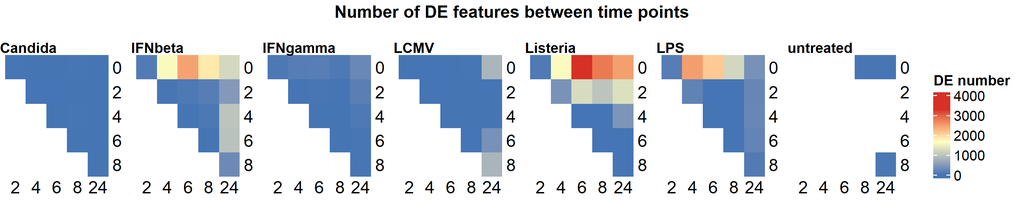

```r
plot_DE_between_time(DE_between_time_out,
    fontsize = 8, value = FALSE, nrow = 1, heatmap_width = 3
)
```

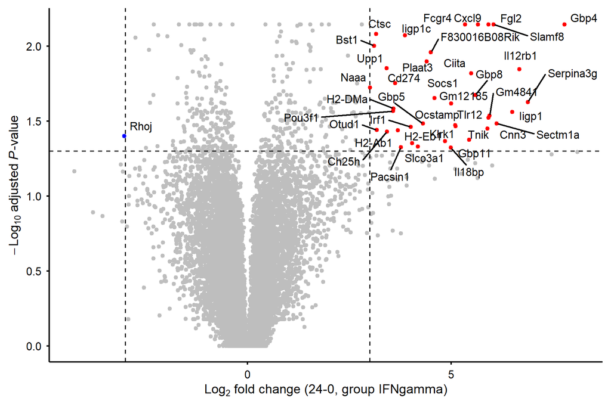

```r
plot_volcano(DE_between_time_out,
    group = "IFNgamma", time1 = 0, time2 = 24,
    logFC_thres = 3, adjP_thres = 0.05, label = TRUE)
```

## 8.2 Between groups at each time point

Default DE criteria: p.adj < 0.05, |log2FC| > 1. `trend = TRUE` for RNA-seq.

All groups use untreated time 0 data, so no DE features at time point 0

```r
DE_between_group_out <- DE_between_group(data_obj, assay = 2,
    group = "untreated", trend = TRUE)
```

```
#> Non-NA replicate number filter not specified. Using minimum number of replicates across all groups and time points: 0
#> Comparing Candida vs untreated: time points only in untreated: none; only in Candida: 2, 4, 6
#> Comparing group Candida to untreated at Time 0: keeping 20150 of 20150 features (100.0%)
#> Warning: Zero sample variances detected, have been offset away from zero
#> Comparing group Candida to untreated at Time 8: keeping 20150 of 20150 features (100.0%)
#> Warning: Zero sample variances detected, have been offset away from zero
#> Comparing group Candida to untreated at Time 24: keeping 20150 of 20150 features (100.0%)
#> Warning: Zero sample variances detected, have been offset away from zero
#> Comparing IFNbeta vs untreated: time points only in untreated: none; only in IFNbeta: 2, 4, 6
#> Comparing group IFNbeta to untreated at Time 0: keeping 20150 of 20150 features (100.0%)
#> Warning: Zero sample variances detected, have been offset away from zero
#> Comparing group IFNbeta to untreated at Time 8: keeping 20150 of 20150 features (100.0%)
#> Warning: Zero sample variances detected, have been offset away from zero
#> Comparing group IFNbeta to untreated at Time 24: keeping 20150 of 20150 features (100.0%)
#> Warning: Zero sample variances detected, have been offset away from zero
#> Comparing IFNgamma vs untreated: time points only in untreated: none; only in IFNgamma: 2, 4, 6
#> Comparing group IFNgamma to untreated at Time 0: keeping 20150 of 20150 features (100.0%)
#> Warning: Zero sample variances detected, have been offset away from zero
#> Comparing group IFNgamma to untreated at Time 8: keeping 20150 of 20150 features (100.0%)
#> Warning: Zero sample variances detected, have been offset away from zero
#> Comparing group IFNgamma to untreated at Time 24: keeping 20150 of 20150 features (100.0%)
#> Warning: Zero sample variances detected, have been offset away from zero
#> Comparing LCMV vs untreated: time points only in untreated: none; only in LCMV: 2, 4, 6
#> Comparing group LCMV to untreated at Time 0: keeping 20150 of 20150 features (100.0%)
#> Warning: Zero sample variances detected, have been offset away from zero
#> Comparing group LCMV to untreated at Time 8: keeping 20150 of 20150 features (100.0%)
#> Warning: Zero sample variances detected, have been offset away from zero
#> Comparing group LCMV to untreated at Time 24: keeping 20150 of 20150 features (100.0%)
#> Warning: Zero sample variances detected, have been offset away from zero
#> Comparing Listeria vs untreated: time points only in untreated: none; only in Listeria: 2, 4, 6
#> Comparing group Listeria to untreated at Time 0: keeping 20150 of 20150 features (100.0%)
#> Warning: Zero sample variances detected, have been offset away from zero
#> Comparing group Listeria to untreated at Time 8: keeping 20150 of 20150 features (100.0%)
#> Warning: Zero sample variances detected, have been offset away from zero
#> Comparing group Listeria to untreated at Time 24: keeping 20150 of 20150 features (100.0%)
#> Warning: Zero sample variances detected, have been offset away from zero
#> Comparing LPS vs untreated: time points only in untreated: none; only in LPS: 2, 4, 6
#> Comparing group LPS to untreated at Time 0: keeping 20150 of 20150 features (100.0%)
#> Warning: Zero sample variances detected, have been offset away from zero
#> Comparing group LPS to untreated at Time 8: keeping 20150 of 20150 features (100.0%)
#> Warning: Zero sample variances detected, have been offset away from zero
#> Comparing group LPS to untreated at Time 24: keeping 20150 of 20150 features (100.0%)
#> Warning: Zero sample variances detected, have been offset away from zero
```

```r
DE_between_group_out$all_list$`IFNgamma-untreated`$`24` |> head()
```

|  | Feature | Comparison | Time | Cond1 | Cond2 | RNA_untreated_24h_R1_2 | RNA_untreated_24h_R2_2 | RNA_IFNgamma_24h_R1_2 | RNA_IFNgamma_24h_R2_2 | logFC | P.Value | adj.P.Val |
| --- | --- | --- | --- | --- | --- | --- | --- | --- | --- | --- | --- | --- |
| 1 | 0610005C13Rik | IFNgamma-untreated | 24 | untreated | IFNgamma | 0.0000000 | 0.4668228 | 0.0000000 | 0.00000000 | -0.2334114 | 0.37030789 | 0.7140896 |
| 2 | 0610009E02Rik | IFNgamma-untreated | 24 | untreated | IFNgamma | -0.5233256 | -0.5233256 | 0.2400274 | -0.07083834 | 0.6079201 | 0.03586013 | 0.2221252 |
| 3 | 0610009L18Rik | IFNgamma-untreated | 24 | untreated | IFNgamma | -0.3091766 | 1.0557975 | -0.7818365 | 0.09318358 | -0.7176369 | 0.41881799 | 0.7760881 |
| 4 | 0610030E20Rik | IFNgamma-untreated | 24 | untreated | IFNgamma | -0.1965651 | 0.1569204 | -0.3169119 | -0.18483718 | -0.2310522 | 0.29189258 | 0.7140896 |
| 5 | 0610039K10Rik | IFNgamma-untreated | 24 | untreated | IFNgamma | 0.0000000 | 0.8189527 | 1.0329095 | 0.45248727 | 0.3332220 | 0.53088273 | 0.9159420 |
| 6 | 0610043K17Rik | IFNgamma-untreated | 24 | untreated | IFNgamma | 0.6608775 | 0.4668228 | 0.7633530 | 0.00000000 | -0.1821737 | 0.65470634 | 1.0000000 |

```r
DE_between_group_out$de_list$`IFNgamma-untreated` |> head()
```

|  | Feature | Comparison | Time | Cond1 | Cond2 | logFC | adj.P.Val |
| --- | --- | --- | --- | --- | --- | --- | --- |
| 1 | Acvrl1 | IFNgamma-untreated | 24 | untreated | IFNgamma | 2.216238 | 0.02331017 |
| 2 | Aif1 | IFNgamma-untreated | 24 | untreated | IFNgamma | 3.817541 | 0.02331017 |
| 3 | Aig1 | IFNgamma-untreated | 24 | untreated | IFNgamma | 2.236541 | 0.03759957 |
| 4 | Akap13 | IFNgamma-untreated | 24 | untreated | IFNgamma | 1.041933 | 0.01909473 |
| 5 | Alcam | IFNgamma-untreated | 24 | untreated | IFNgamma | -1.175958 | 0.04766911 |
| 6 | Ambp | IFNgamma-untreated | 24 | untreated | IFNgamma | -2.676635 | 0.02592126 |

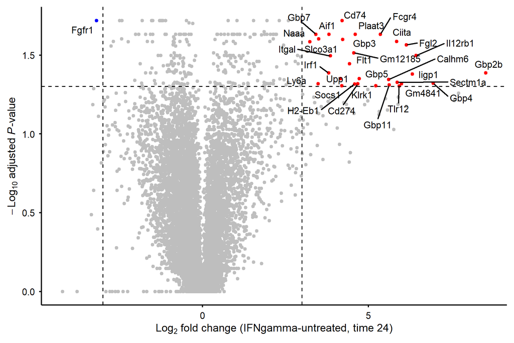

```r
plot_volcano(DE_between_group_out,
    group1 = "untreated", group2 = "IFNgamma", time = 24,
    logFC_thres = 3, adjP_thres = 0.05, label = TRUE)
```

The `group` parameter of `plot_DE_between_group` restricts the plotting to comparisons versus a specific group.

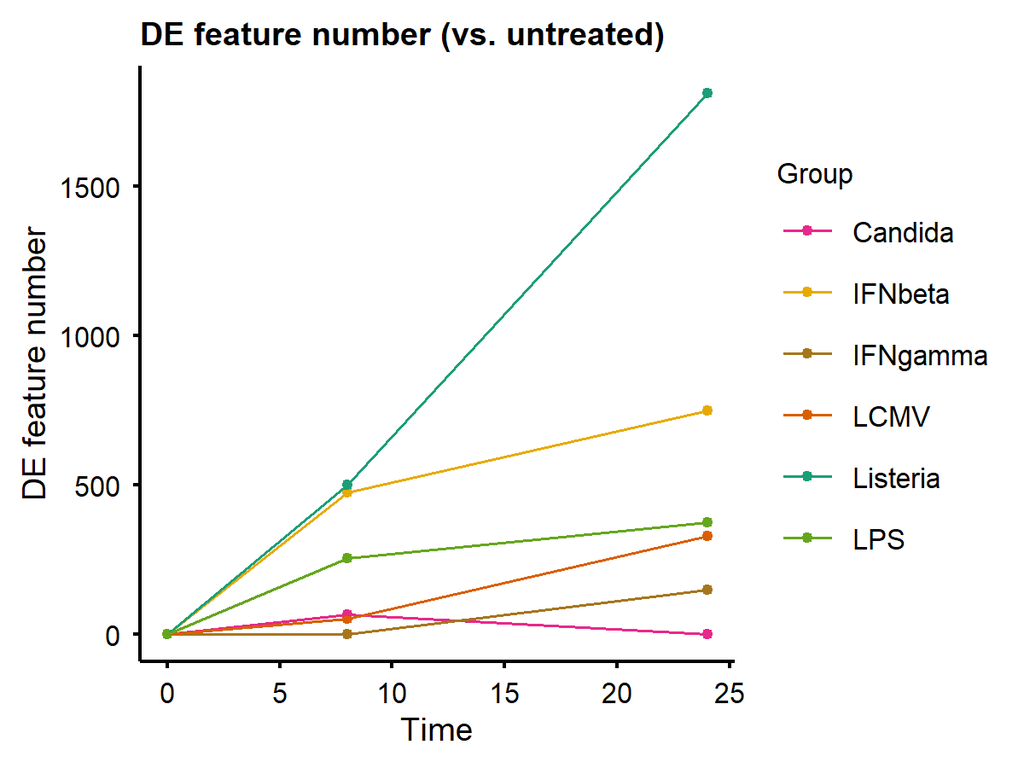

```r
plot_DE_between_group(DE_between_group_out,
    group = "untreated", fontsize = 8)
```

# 9 Overall temporal differential expression

`DE_timecourse()` tests whether each feature changes over the full time course within each group or across groups (`group_mode = "per_group"` or `"joint_group"`), complementing the pairwise tests above.

With `time_mode = "factor"`, the omnibus F-test evaluates all time-point effects without assuming a linear or smooth trend.

```r
DE_timecourse_out <- DE_timecourse(data_obj, assay = 1,
    group_mode = "per_group", time_mode = "factor", trend = TRUE)
DE_timecourse_out$results$time_effect |>
    dplyr::filter(adj.P.Val < 0.05) |>
    dplyr::count(Group, name = "N_features")
```

| Group | N_features |
| --- | --- |
| Candida | 209 |
| IFNbeta | 6561 |
| IFNgamma | 2110 |
| LCMV | 895 |
| LPS | 5552 |
| Listeria | 7217 |
| untreated | 498 |

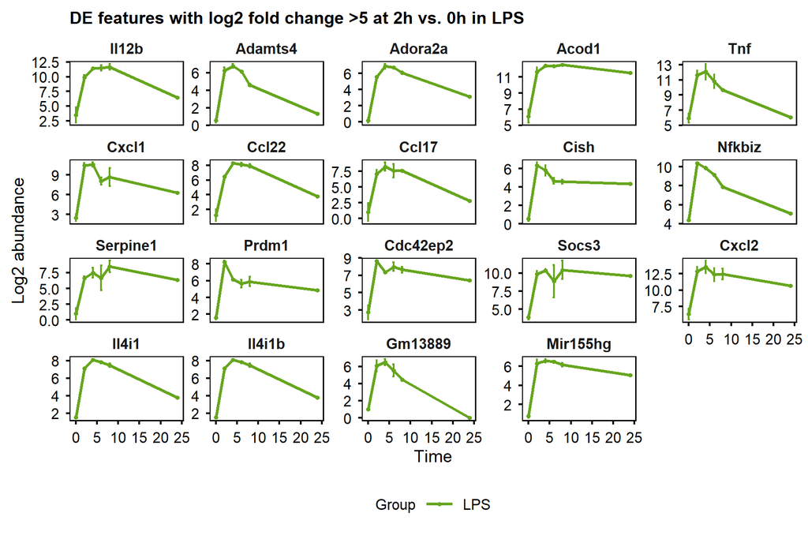

```r
plot_trend(data_obj,
    features = DE_timecourse_out$results$time_effect |>
        filter(adj.P.Val < 0.05 & logFC_TimeFactor2 > 5 & Group == "LPS") |>
        pull(Feature) |> unique(),
    groups = "LPS",
    title = "DE features with log2 fold change >5 at 2h vs. 0h")
```

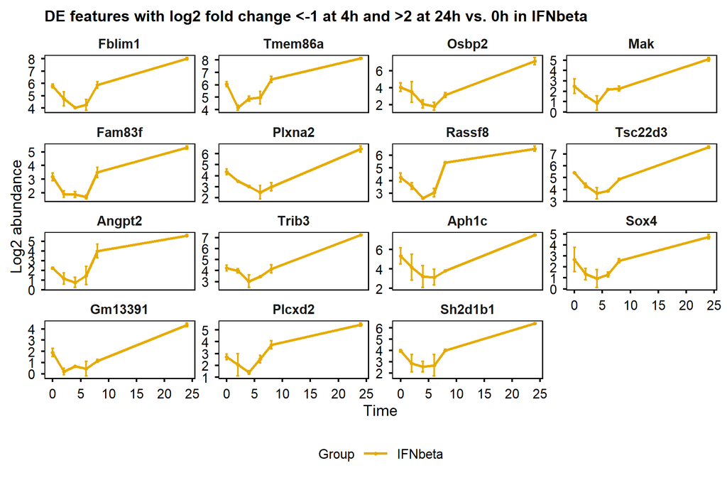

```r
plot_trend(data_obj,
    features = DE_timecourse_out$results$time_effect |>
        filter(adj.P.Val < 0.05 & logFC_TimeFactor4 < -1 &
            logFC_TimeFactor24 > 2 & Group == "IFNbeta") |>
        pull(Feature) |> unique(),
    groups = "IFNbeta",
    title = "DE features with log2 fold change <-1 at 4h and >2 at 24h vs. 0h")
```

With `time_mode = "numeric"`, a linear temporal change is tested. Using `group_mode = "joint_group"`, the slope difference between groups is provided.

Only time points shared by all groups (0, 8, 24) are used.

```r
DE_timecourse_linear <- DE_timecourse(data_obj, assay = 1,
    reference_group = "untreated",
    group_mode = "joint_group", time_mode = "numeric", trend = TRUE)
```

```
#> Some Group-Time combinations contain only one sample; replicate-level variance cannot be estimated for them.
#> Warning: Zero sample variances detected, have been offset away from zero
#> Warning: Zero sample variances detected, have been offset away from zero
```

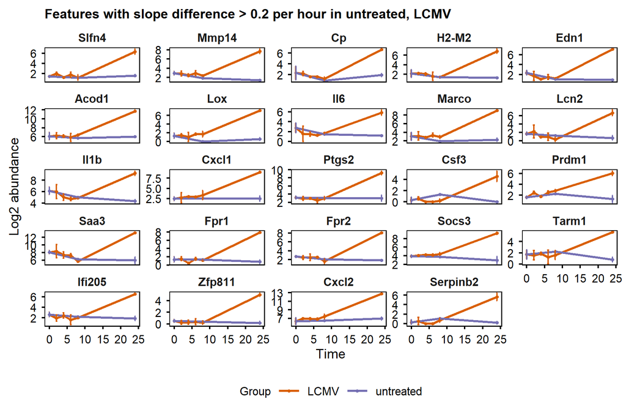

```r
plot_trend(data_obj,
    groups = c("untreated", "LCMV"),
    features = DE_timecourse_linear$results$group_time_interaction |>
        filter(delta_logFC_GroupLCMV_TimeSlope > 0.2) |>
        pull(Feature) |> unique(),
    title = "Features with slope difference > 0.2 per hour")
```

With `time_mode = "spline"`, smooth nonlinear trends can be fit.

# 10 Differentially expressed genes (DEG) classified by feature properties

## 10.1 Calculate feature properties (expression ratio, maximum overall fold change, etc.)

use data not normalised to time 0, replicates merged by mean.

```r
data_obj_merged_list <- calc_feature_property(data_obj_merged_list, threshold = 0)
property_fc <- summarise_feature_property(data_obj_merged_list)

head(property_fc)
```

|  | Feature | Group | Exp_threshold | T_exp | T_total | P_trend | Max_FC | Max_FC_time | Net_FC | Rho_time | Peak_ratio | Log2_CV | AUC | Exp_ratio |
| --- | --- | --- | --- | --- | --- | --- | --- | --- | --- | --- | --- | --- | --- | --- |
| 1 | 0610005C13Rik | Candida | 0 | 1 | 6 | NA | 0.4183156 | 4 | 0.0000000 | NA | NA | NA | 0.8366312 | 0.1666667 |
| 2 | 0610009E02Rik | Candida | 0 | 5 | 6 | 0.5000000 | 0.9759878 | -2 | -0.3104196 | -0.65714286 | 0.3333333 | 0.97930681 | -6.0347859 | 0.8333333 |
| 3 | 0610009L18Rik | Candida | 0 | 6 | 6 | 0.7699851 | 1.2845689 | 16 | 1.0802744 | 0.42857143 | 0.1666667 | 0.35850838 | 10.3087486 | 1.0000000 |
| 4 | 0610030E20Rik | Candida | 0 | 6 | 6 | 0.6592596 | 0.3859150 | -2 | -0.1073578 | -0.02857143 | 0.1666667 | 0.03698154 | -4.4039273 | 1.0000000 |
| 5 | 0610039K10Rik | Candida | 0 | 1 | 6 | NA | 0.1801653 | 2 | 0.0000000 | NA | NA | NA | 0.3603305 | 0.1666667 |
| 6 | 0610043K17Rik | Candida | 0 | 2 | 6 | NA | 0.5134031 | 2 | 0.0000000 | NA | NA | NA | 1.3734331 | 0.3333333 |

`plot_scatter()` can be used to compare properties from two groups, or compare two properties from one table.

```
#> Ignoring 4471 feature pair(s) with missing or infinite values.
```

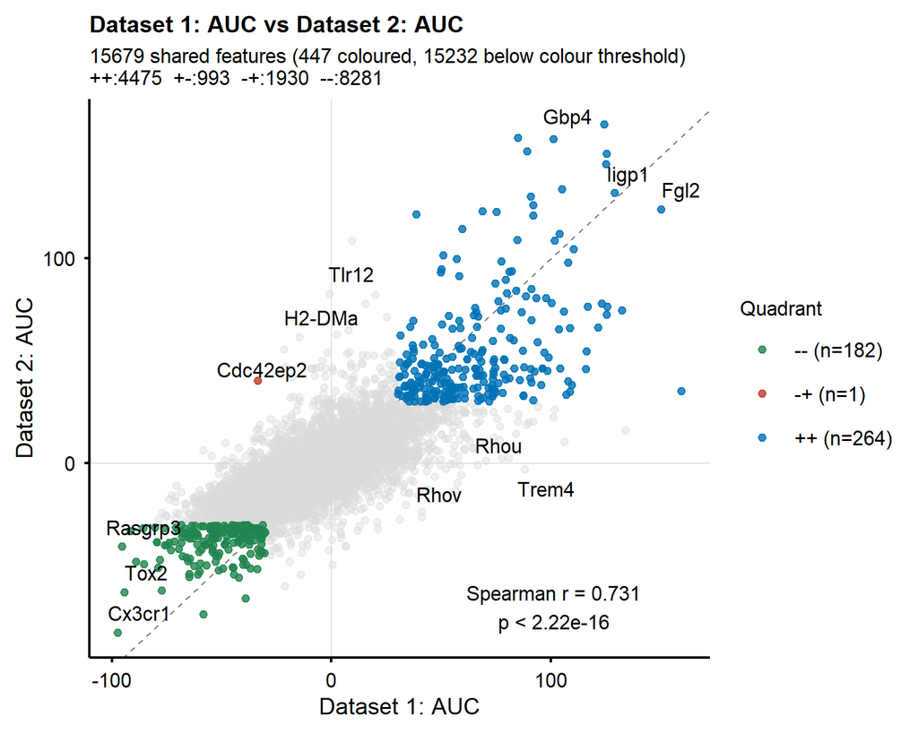

```r
plot_scatter(
    property_fc |> filter(Group == "IFNbeta"),
    property_fc |> filter(Group == "IFNgamma"),
    col1 = "AUC", col2 = "AUC",
    label_top_n = 3, colour_threshold = 30)
```

```
#> Ignoring 3281 feature pair(s) with missing or infinite values.
```

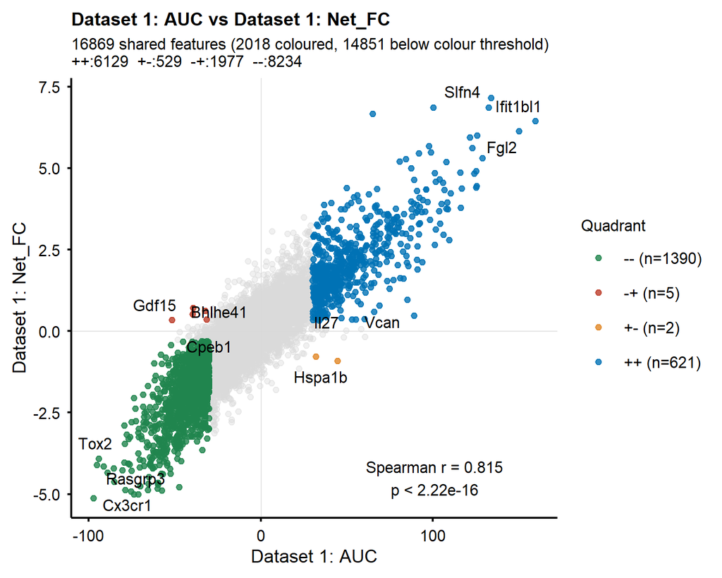

```r
plot_scatter(
    property_fc |> filter(Group == "IFNbeta"),
    col1 = "AUC", col2 = "Net_FC",
    label_top_n = 3, colour_threshold = c(x = 30, y = 0.3))
```

## 10.2 Non-random DEG in each group

DEG: max overall fold change >= fold change threshold (2 fold)

```r
filter_list <- list() # genes with at least certain values > threshold (0)

non_random_list <- list()
non_random_up_list <- list()
non_random_down_list <- list()

filter_ratio <- 0.5 # minimum expressed in 50% samples
max_fc_thres <- 1 # two fold changes in log2 scale

for (i in unique(data_obj$Group)) {
    filter_list[[i]] <- property_fc |>
        filter(Group == i) |>
        filter(Exp_ratio > filter_ratio) |>
        pull(Feature)

    non_random_list[[i]] <- property_fc |>
        filter(Group == i) |>
        filter(P_trend < 0.05 & Exp_ratio > filter_ratio) |>
        pull(Feature)

    non_random_up_list[[i]] <- property_fc |>
        filter(Group == i) |>
        filter(P_trend < 0.05 & Exp_ratio > filter_ratio &
            Max_FC >= max_fc_thres & Max_FC_time > 0) |>
        pull(Feature)
    non_random_down_list[[i]] <- property_fc |>
        filter(Group == i) |>
        filter(P_trend < 0.05 & Exp_ratio > filter_ratio &
            Max_FC >= max_fc_thres & Max_FC_time < 0) |>
        pull(Feature)
}
```

```r
non_random_up_list |> lapply(length)
```

```
#> $Candida
#> [1] 119
#>
#> $IFNbeta
#> [1] 546
#>
#> $IFNgamma
#> [1] 389
#>
#> $LCMV
#> [1] 470
#>
#> $Listeria
#> [1] 638
#>
#> $LPS
#> [1] 401
#>
#> $untreated
#> [1] 0
non_random_down_list |> lapply(length)
```

```
#> $Candida
#> [1] 85
#>
#> $IFNbeta
#> [1] 1863
#>
#> $IFNgamma
#> [1] 535
#>
#> $LCMV
#> [1] 556
#>
#> $Listeria
#> [1] 2791
#>
#> $LPS
#> [1] 1447
#>
#> $untreated
#> [1] 0
```

## 10.3 Overlap of temporal features across groups

Using sets of features from different groups, the UpSet plot shows shared and group-specific temporal features.

```
#> Warning in plot_upset_v(non_random_list): Removing empty set(s): untreated
#> Intersection pattern to label mapping:
#>   111111: Candida_IFNbeta_IFNgamma_LCMV_Listeria_LPS
#>   111110: Candida_IFNbeta_IFNgamma_LCMV_Listeria
#>   111011: Candida_IFNbeta_IFNgamma_Listeria_LPS
#>   110111: Candida_IFNbeta_LCMV_Listeria_LPS
#>   011111: IFNbeta_IFNgamma_LCMV_Listeria_LPS
#>   111100: Candida_IFNbeta_IFNgamma_LCMV
#>   111010: Candida_IFNbeta_IFNgamma_Listeria
#>   111001: Candida_IFNbeta_IFNgamma_LPS
#>   110110: Candida_IFNbeta_LCMV_Listeria
#>   110101: Candida_IFNbeta_LCMV_LPS
#>   110011: Candida_IFNbeta_Listeria_LPS
#>   101110: Candida_IFNgamma_LCMV_Listeria
#>   101101: Candida_IFNgamma_LCMV_LPS
```

[output cut: 48 more lines]

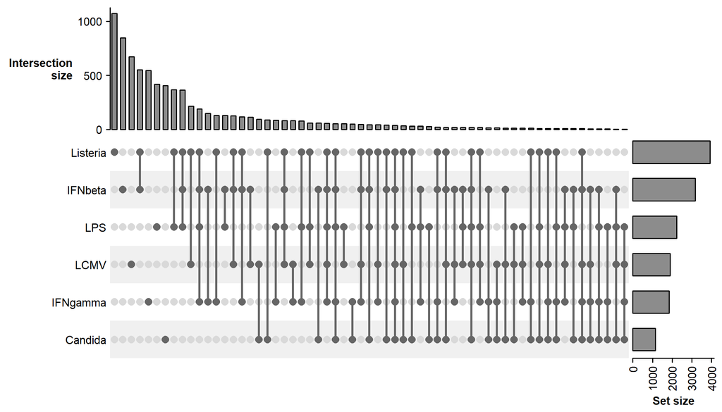

```r
plot_upset_v(non_random_list)
```

The untreated group with only 3 time points doesn’t have non-random DEG.